# First simulations for GxE in families

Andrey Ziyatdinov

2016-12-06

# About

Consider:

- A cohort of unrelated individuals and the linear regression framework;
- An environmental exposure variable `E` with 2 categorical levels: exposed and unexposed;
- Genotyped markers (SNPs) `G` available at genome-wide scale;
- The analysis to detect gene-environment interaction `GxE`.

Two approaches to detect `GxE`

1. A single regression on total sample testing of interaction effect term in linear regression
   - $Z^2 = (\frac{\beta}{se_\beta})^2 \sim \chi^2_1$;
2. Stratified framework of two regressions per strata (Randall et al. 2013);
   - $Z^2 = (\frac{\beta_1 - \beta_0}{se_{\beta_1}^2 + se_{\beta_0}^2 - 2 r se_{\beta_1} se_{\beta_0}})^2 \sim \chi^2_1$,
   - where $r$ is the Spearman rank correlation coefficient between $\beta_1$ and $\beta_0$, calculated from the genome-wide results.

seem to show close equivalence in cohorts of **unrelated** individuals of large sample size (references?).

The intuition behind the stratified framework is analogy of taking the difference between two random variables, and the large sample size allows to approximate well the distribution of effects in stratas to the Gaussian.

## Problem statement

How will the two test perform in a cohort of related individuals? The direct consequence is change from linear regression to mixed-effect linear regression.

While simulations are good to draw conclusions on a grid of parameters, one need some previous guesses on why some things might behave differently in comparison to unrelated samples. Our guesses:

- Guess 1: Biased estimation of variance components might affect the mutual test performance.
  - Remember: the residual variance partially defines the power to detect the interaction effect.
  - The less variance is explained, the less power is expected.
- Guess 2: Estimation of the correlation coefficient $r$ might needs a different formula for the mixed model. The use of $cov(\beta_0, \beta_1)$ for that might be inappropriate.

### In this report

In this report we focus on Guess 1 and explore three modes of phenotype simulation:

- `famgen`: `int * G * E + (1|FAM) + (1|ID) + R`;
- `fam`: `int * G * E + (1|FAM) + R`;
- `gen`: `int * G * E + (1|ID) + R`.

As a reference simulation, we generate phenotypes with no random effects:

- `no_random`: `Y <- int * G * E + R`.

### In the next report

In the next report we will address Guess 2. A possible way to go might be WLS.

# Previous results

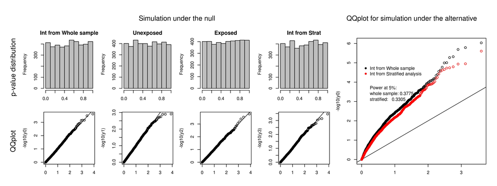

# Fixes in previous code

Previous code: toyExample_v4.0.r

[Line 72](https://github.com/hemostat/simulations/blob/master/01-stratified-gxe/docs/sim1-from-Hugo-nuclear-fam/toyExample_v4.0.r#L72)

```
G   <- c(G,Gc)
```

Genotypes are drawn correctly, but the joining results is wrong.

[Line 113](https://github.com/hemostat/simulations/blob/master/01-stratified-gxe/docs/sim1-from-Hugo-nuclear-fam/toyExample_v4.0.r#L113)

```
stratCov    <- cov(Sune[myNull,1],Sexp[myNull,1])
pCor        <- pchisq(((eff[,1])^2 / (eff[,2]^2 - 2*stratCov)), 1, lower.tail=F)
```

The Spearman correlation is needed, while `cov` function is about the Pearson correlation.

[Line 47](https://github.com/hemostat/simulations/blob/master/01-stratified-gxe/docs/sim1-from-Hugo-nuclear-fam/toyExample_v4.0.r#L47)

```
Renv    <- as.vector(t(matrix(rep(rnorm(Nfam),Ni),Nfam,Ni)))
```

# `gxefam` R package

See github.com/hemostat/gxefam (a private repository).

Loading package:

```r
load_all("~/git/hemostat/gxefam/")
```

A really toy example:

```r
par <- gxefam_par(num_fam = 20, num_sim_null = 2, num_sim_alt = 2, sim_phen = "gen", fit = "relmatLmer")
par
```

```
 - num_total 100: num_fam 20, size_fam 5
 - num_sim_null 2, num_sim_alt 2
 - sim_gen 'rbinom_fam', sim_phen 'gen'; fit 'relmatLmer'
 - var_fam 0, var_gen 0.3; var_explained 0.3
 - int 0.1; freq_g 0.3; freq_e 0.3
```

```r
run <- gxefam_run(par, verbose = 0, seed = 1)
run
```

```
 *** Input parameters ***
 - num_total 100: num_fam 20, size_fam 5
 - num_sim_null 2, num_sim_alt 2
 - sim_gen 'rbinom_fam', sim_phen 'gen'; fit 'relmatLmer'
 - var_fam 0, var_gen 0.3; var_explained 0.3
 - int 0.1; freq_g 0.3; freq_e 0.3
 *** Output ***
 - power: total 0, strat_uncor 0, strat_cor 0.5 (rho_strat 1)
```

# Replication of previous result using `gxefam`

The simulation model here is `famgen`.

```
 *** Input parameters ***
 - num_total 2,500: num_fam 500, size_fam 5
 - num_sim_null 20,000, num_sim_alt 10,000
 - sim_gen 'rbinom_fam', sim_phen 'famgen'; fit 'relmatLmer'
 - var_fam 0.3, var_gen 0.3; var_explained 0.6
 - int 0.1; freq_g 0.3; freq_e 0.3
 *** Output ***
 - power: total 0.447, strat_uncor 0.296, strat_cor 0.358 (rho_strat 0.167)
```

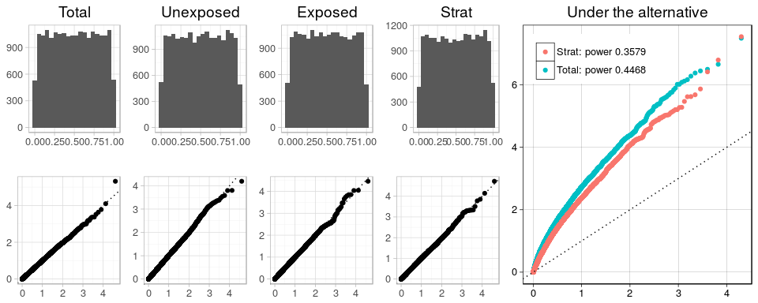

## Was it crucial to switch to Spearman?

The plot of simulation results for the case of using the Pearson correlation coefficient.

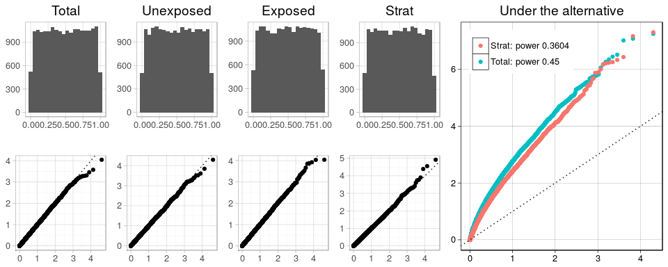

Answer: no. The simulation results are almost the same in comparison with that of Spearman.

## Extension of previous example for several additional modes

Columns meaning:

- `power_total`: the power at `alpha` threshold for the standard interaction test in total sample;
- `power_strat_cor`: the power for the stratified test, corrected using estimation of correlation `rho_strat`;
- `power_strat_uncor`: the power for the stratified test (uncorrected).

| sim_phen | power_total | power_strat_cor | power_strat_uncor | rho_strat | num_sim_alt | alpha |
| --- | --- | --- | --- | --- | --- | --- |
| no_rand | 0.6566 | 0.6568 | 0.6577 | -0.0020 | 10,000 | 0.05 |
| fam | 0.5716 | 0.4020 | 0.3547 | 0.1221 | 10,000 | 0.05 |
| famgen | 0.4468 | 0.3579 | 0.2961 | 0.1670 | 10,000 | 0.05 |
| gen | 0.3916 | 0.3449 | 0.2832 | 0.1608 | 10,000 | 0.05 |

Observations:

- As expected, there is no difference between the two tests for `no_rand`.
- The drop in power for related samples (`fam`, `gen` and `famgen` *vs.* `no_rand`) is likely due to `gen` component.
  - Otherwise, the drop for `fam` and `gen` *vs.* `no_rand` would be similar (it is not).
- Having 2 rather than 1 variance components also might be an issue.

It is not clear what is a connection between estimation of variance components and estimation of correlation coefficient required for the stratified test. The next simulation `fam_envfam` helps to get some insights.

Under `fam_envfam`, the exposure variable `E` is generated with the same frequency `0.3`, but all individuals within family have the same exposure status. That yields the correlation coefficient between strata close to zero.

[output not shown]

The results show that there is no difference between the two tests. At the same time, it is not clear what was the reason of drop in power.

# Power as a function of `int`

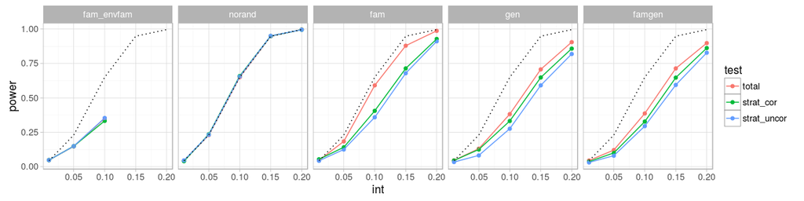

# Power as a function of `int` and `var_explained`

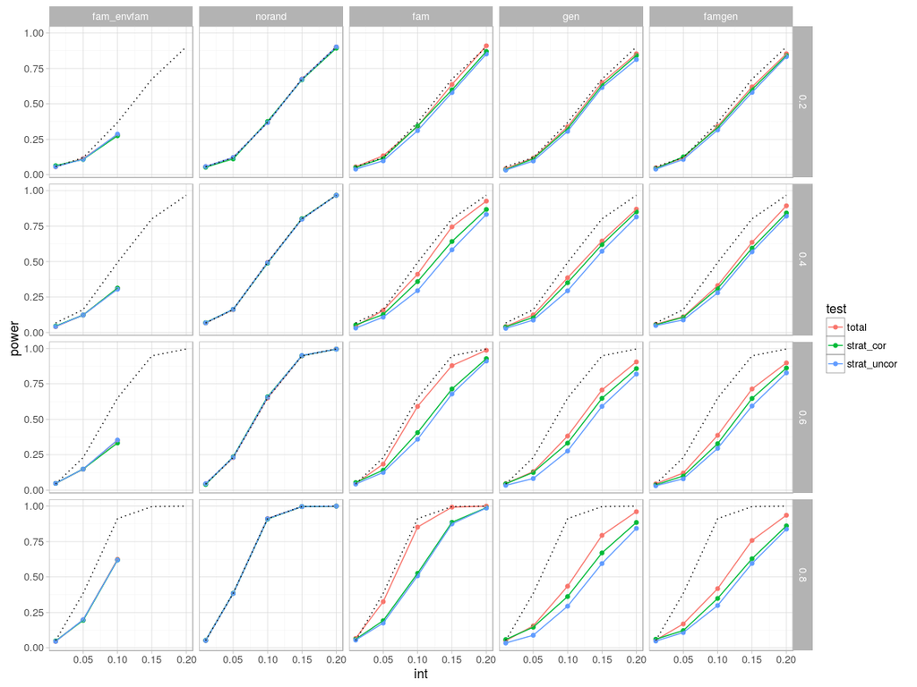

# Correlation between strata as a function of `int` and `var_explained`

Note that here we plot our **estimation** of correlation between stratas. There are clear two groups of simulations:

- `no_rand` and `fam_envfam` with correlations next to zero.
- `fam`, `gen`, `famgen` with non-zero correlations.

The point is that estimation of correlation for `fam`, `gen`, `famgen` might be not correct.

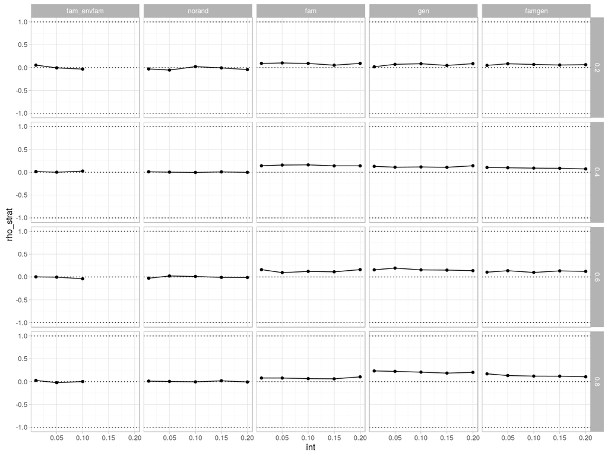

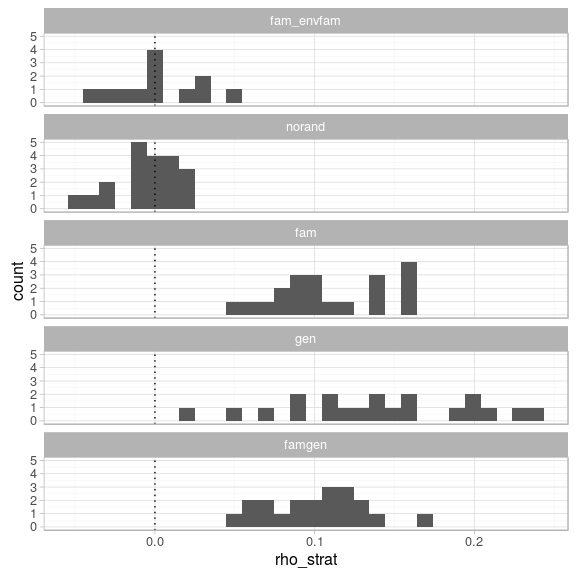

References

Randall, Joshua C, Thomas W Winkler, Zoltán Kutalik, Sonja I Berndt, Anne U Jackson, Keri L Monda, Tuomas O Kilpeläinen, et al. 2013. “Sex-Stratified Genome-Wide Association Studies Including 270,000 Individuals Show Sexual Dimorphism in Genetic Loci for Anthropometric Traits.” *PLoS Genet* 9 (6). Public Library of Science: e1003500.